# BIKE PARKING DOWNTOWN LONDON, ON

March 28, 2019 For R-Ladies London, ON

By Rebecca Henderson, PhD candidate, Faculty of Health Sciences, Western University

I want to thank the Cycling Advisory Committee and intern students at Thames Regional Ecological Authority for providing the parking data for this project today.

We need to install the development version of ggmaps, and you need to get a google API for Maps Static API. You can read about that [here](https://github.com/dkahle/ggmap#user-content-attention). You will need to set up a a 12-month free trial with google, but you have to give billing information. If you haven’t already set that up and gotten an API key, get one [here](https://developers.google.com/maps/documentation/maps-static/intro#auth) by click on the blue “Get Started” button, then check off “Maps”.

I started off with this tutorial for heatmaps https://www.sharpsightlabs.com/blog/how-to-create-a-crime-heatmap-in-r/

```r
# if(!requireNamespace("devtools")) install.packages("devtools")
# devtools::install_github("dkahle/ggmap", ref = "tidyup")
```

```r
library(tidyverse)
library(ggmap)
library(stringr)
library(viridis)
```

```r
library(ggplot2)
```

Change “YOUR-API-KEY-HERE” to your API key in quotes. Don’t share this number with anyone, it’s like a password.

```r
register_google("YOUR-API-KEY-HERE")
```

It’s great to be able to import your data directly from excel!

```r
BikeParking <- read_csv("BikeParking_Feb16.csv")
colnames(BikeParking)[1:2] <- c("Latitude","Longitude")
```

# SIMPLE SCATTERPLOT

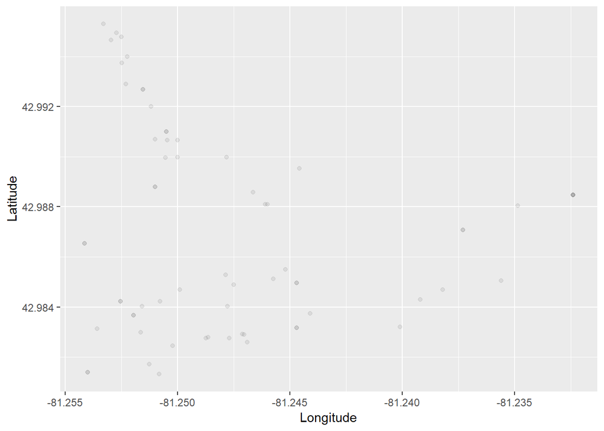

```r
ggplot() +
  geom_point(data = BikeParking, aes(x = Longitude, y = Latitude), alpha = .07)
```

# SIMPLE HEATMAP

Divides the plane into rectangles, counts the number of cases in each rectangle, and then (by default) maps the number of cases to the rectangle’s fill.

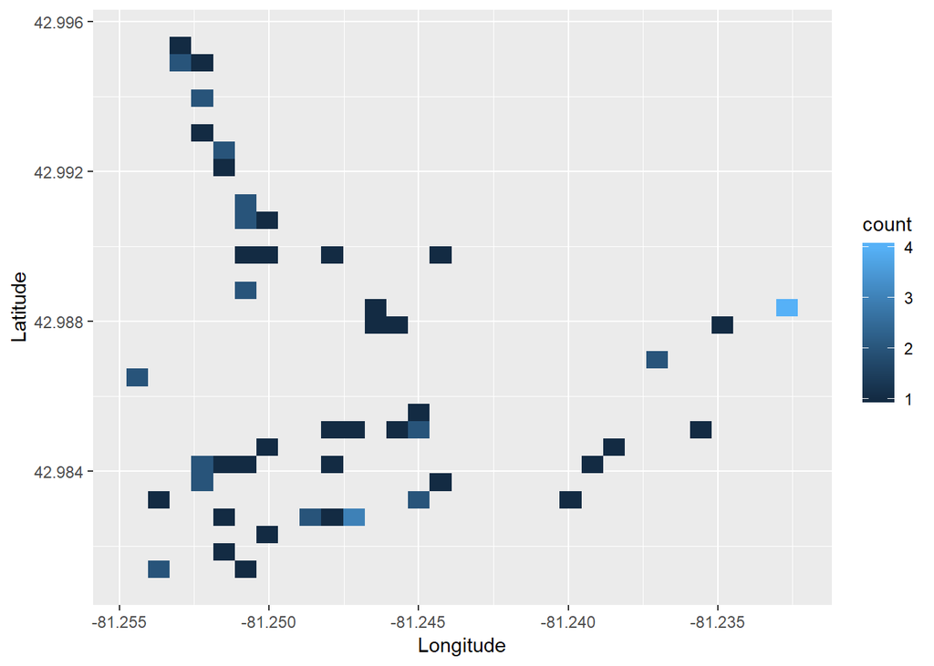

```r
ggplot() +
  stat_bin_2d(data = BikeParking, aes(x = Longitude, y = Latitude, fill = ..count..), geom = 'tile')
```

# GET MAP

```r
# map_london <- get_map(
#   location = c(Longitude=mean(BikeParking$Longitude), Latitude=mean(BikeParking$Latitude)),
#   zoom=15,
#   maptype = 'roadmap')
#saveRDS(map_london,"map_london.rds")

map_london <- readRDS("map_london.rds")
```

# PLOT BASIC LONDON MAP

Check if the zoom is okay. If not, change the `zoom=15` argument in the chunk of code above. Note: The maptype options available are “terrain”, “satellite”, “roadmap”, and “hybrid”. zoom=3 is continent. zoom=20 is approx a city block. I like this cheatsheet: https://www.nceas.ucsb.edu/~frazier/RSpatialGuides/ggmap/ggmapCheatsheet.pdf

[figure not shown]

```r
ggmap(map_london)
```

# LABELS

[figure not shown]

```r
ggmap(map_london) +
  geom_point(data = BikeParking,
             aes(x = Longitude, y = Latitude),
             alpha = .7, color="red") +
  geom_text(data = BikeParking,
            aes(x = Longitude, y = Latitude, label=paste0(Road1,"_",Road2)),
            size=3.5, color="red", alpha=0.6, fontface = "bold", show.legend = FALSE)
```

# Organizing data

```r
# # to make longitude and latitude the same for each location. Bike parking at Piccadilly St. and Richmond St. is the same as Richmond St. and Piccadilly St, but R doesn't know that. :)
## group data by road1 and road2, take the average lat and long for each group
# BikeParking2 <- BikeParking %>%
#   rowwise() %>%
#   mutate(R1 = sort(c(Road1, Road2))[1], R2 = sort(c(Road1, Road2))[2]) %>%
#   ungroup() %>%
#   select(-Road1,-Road2)
#
#
# # count the number of bike parking per group.
# BikeParking_summary <- BikeParking2 %>%
#   group_by(R1, R2) %>%
#   summarise(N=n(), Latitude = mean(Latitude), Longitude=mean(Longitude))
#
# # Merge back to the data and replace the old longitude and latitude
# BikeParking2 <- BikeParking2 %>%
#   select(-Latitude,-Longitude) %>%
#   left_join(BikeParking_summary,c("R1","R2"))
```

# HEATMAP OVERLAY

[figure not shown]

```r
# MAP WITH HEATMAP OVERLAY
ggmap(map_london) +
  stat_bin_2d(data = BikeParking, aes(x = Longitude, y = Latitude, fill = stat(count)),
             # binwidth = c(0.001, 0.001),
              geom = 'tile',  alpha=.5) +
  scale_fill_viridis()
```

# POLISHED HEATMAP

```r
final_map <- ggmap(map_london) +
  stat_bin_2d(data = BikeParking, aes(x = Longitude, y = Latitude, fill = stat(count)),
              binwidth = c(0.001, 0.001),
              geom = 'tile',  alpha=.5) +
  scale_fill_viridis(option = 'cividis') +
  labs(title = str_c('Bike parking\n', #<-- the \n adds a line break
                     'downtown London'
                     ),
       subtitle = 'Just for learning purposes',
       fill = str_c('Number of', '\nbikeparking')
       ) +
  theme(text = element_text(color = "#444444"),
        plot.title = element_text(size = 22, face = 'bold'),
        plot.subtitle = element_text(size = 12),
        axis.text = element_blank(),
        axis.title = element_blank(),
        axis.ticks = element_blank()
        ) +
  guides(fill = guide_legend(override.aes= list(alpha = 1)))
```

Preview your final map: (this could take some time)

[figure not shown]

```r
final_map
```

Save your final map as a png. You can change the width and height of the final image here as well:

```r
ggsave(filename = "bike_parking_heatmap.png", units="cm", width=20, height=20)
```

# POLISHED POINTMAP

For bike parking, we want to know the exact location of a bike rack, so this is a silly example. (We also don’t have a large enough data set.) However, point maps are very useful to cluster incidences of crime, income levels by neighbourhood, electoral voting patterns, etc.

[figure not shown]

```r
# group data by road1 and road2, take the average lat and long for each group
# count the number of bike parking per group.
BikeParking_summary <- BikeParking %>%
  rowwise() %>%
  mutate(R1 = sort(c(Road1, Road2))[1], R2 = sort(c(Road1, Road2))[2]) %>%
  ungroup() %>%
  select(-Road1,-Road2) %>%
  group_by(R1, R2) %>%
  summarise(N=n(), Latitude = mean(Latitude), Longitude=mean(Longitude))

# use the number of collisions per group to determine point size
ggmap(map_london) +
  geom_point(data = BikeParking_summary,
             aes(x = Longitude, y = Latitude, size=N),
             alpha = .7, color="red") +
  geom_text(data = BikeParking_summary,
            aes(x = Longitude, y = Latitude, label=N),
            size=2, color="white",  fontface = "bold", show.legend = FALSE)+
      labs(title = str_c('Bike Parking\n', #<-- the \n adds a line break
                     'downtown London'
                     ),
       subtitle = 'Just for learning purposes',
       size = str_c('Number of', '\nparking spots')
       ) +
  theme(text = element_text(color = "#444444"),
        plot.title = element_text(size = 22, face = 'bold'),
        plot.subtitle = element_text(size = 12),
        axis.text = element_blank(),
        axis.title = element_blank(),
        axis.ticks = element_blank()
        )+
    scale_size_continuous(range = c(2,10))
```

```r
ggsave(filename = "bike_parking_pointmap.png", units="cm", width=20, height=20)
```